# ¿Influye nuestro estilo de vida en el rendimiento académico?

Análisis descriptivo, ACP y Biplot de 1 000 estudiantes · Actividad evaluable 1 · MEA1

Víctor Fabián Novoa Rojas — Maestría en Inteligencia Artificial, Universidad de La Sabana

16/09/2026

# 1 Presentación

## 1.1 Pregunta de investigación

> **¿Cómo se relacionan las horas de estudio y las horas de sueño con el CGPA de los estudiantes, y cómo varía esa relación según la carrera y el nivel de estrés?**

La pregunta involucra dos cuantitativas explicativas (horas de estudio, horas de sueño), una respuesta cuantitativa (CGPA) y dos categóricas (carrera, nivel de estrés). No es cerrada, exige datos con variabilidad y se responde con medidas descriptivas, comparaciones entre grupos, correlaciones y un Análisis de Componentes Principales (ACP) resumido en un Biplot.

## 1.2 Justificación

- **¿Por qué es interesante?** El rendimiento académico se suele atribuir a la dedicación, pero los hábitos de descanso y la tensión que acompaña al estudio también forman parte del día del estudiante. Describir cómo se combinan esas dimensiones aporta una mirada conjunta que una nota aislada no da.
- **¿A quién beneficia?** A estudiantes, que pueden ubicar su propio perfil de hábitos; a docentes y bienestar universitario, que reciben una descripción de qué patrones acompañan a los promedios altos y bajos.
- **¿Qué se aprende?** Qué variables del estilo de vida se asocian linealmente con el CGPA, cuáles no muestran asociación alguna y cómo se resume la estructura conjunta en dos ejes interpretables.
- **¿Qué decisiones permite?** Priorizar qué hábitos vale la pena medir y seguir en programas de acompañamiento. El alcance es **descriptivo**: los resultados describen esta base, no demuestran causas ni se generalizan a una población.

## 1.3 Objetivos

- **General:** describir la relación entre horas de estudio, horas de sueño y CGPA en una base de 1 000 estudiantes, y cómo varía según la carrera y el nivel de estrés.
- **Específicos:** (1) comparar la distribución del CGPA entre carreras, niveles de estrés y perfiles de hábitos; (2) identificar qué variables presentan mayor asociación lineal con el CGPA y resumir la estructura conjunta mediante ACP y Biplot.

## 1.4 Unidad de análisis y tabla de variables

Cada fila es **un estudiante**. No hay identificador ni variable de tiempo, y no hay medidas repetidas.

```r
# Tabla de variables con nombre limpio, etiqueta, tipo, unidad y rol dentro del análisis.
tabla_variables <- data.frame(
  Variable = c("age", "study_hours_per_day", "sleep_hours", "screen_time_hours",
               "gym_hours_per_week", "attendance_percentage", "stress_level_1_to_10",
               "internal_marks", "cgpa", "branch", "diet_type", "residence",
               "nivel_estres", "perfil_habitos"),
  Etiqueta = c("Edad", "Horas de estudio por día", "Horas de sueño por día",
               "Horas de pantalla por día", "Horas de gimnasio por semana",
               "Asistencia", "Nivel de estrés", "Notas internas", "CGPA",
               "Carrera", "Tipo de dieta", "Residencia",
               "Nivel de estrés en 3 niveles", "Perfil estudio × sueño"),
  Tipo = c("Cuantitativa discreta", rep("Cuantitativa continua", 8),
           rep("Cualitativa nominal", 3), "Cualitativa ordinal (derivada)",
           "Cualitativa nominal (derivada)"),
  Unidad = c("años", "horas", "horas", "horas", "horas", "%", "escala 1–10",
             "puntos 0–100", "escala 0–10", "6 categorías", "2 categorías",
             "2 categorías", "terciles de estrés", "medianas de estudio y sueño"),
  Rol = c("Descriptiva, no activa en ACP", "Explicativa, activa en ACP",
          "Explicativa, activa en ACP", "Descriptiva, no activa en ACP",
          "Descriptiva, no activa en ACP", "Activa en ACP", "Activa en ACP",
          "Activa en ACP", "Respuesta, activa en ACP", "Grupo a priori",
          "Grupo a priori", "Grupo a priori", "Grupo derivado (Biplot A)",
          "Grupo derivado (Biplot B)"),
  check.names = FALSE
)
knitr::kable(tabla_variables, caption = "Variables de la base y rol en el análisis.")
```

Variables de la base y rol en el análisis.

| Variable | Etiqueta | Tipo | Unidad | Rol |
| --- | --- | --- | --- | --- |
| age | Edad | Cuantitativa discreta | años | Descriptiva, no activa en ACP |
| study_hours_per_day | Horas de estudio por día | Cuantitativa continua | horas | Explicativa, activa en ACP |
| sleep_hours | Horas de sueño por día | Cuantitativa continua | horas | Explicativa, activa en ACP |
| screen_time_hours | Horas de pantalla por día | Cuantitativa continua | horas | Descriptiva, no activa en ACP |
| gym_hours_per_week | Horas de gimnasio por semana | Cuantitativa continua | horas | Descriptiva, no activa en ACP |
| attendance_percentage | Asistencia | Cuantitativa continua | % | Activa en ACP |
| stress_level_1_to_10 | Nivel de estrés | Cuantitativa continua | escala 1–10 | Activa en ACP |
| internal_marks | Notas internas | Cuantitativa continua | puntos 0–100 | Activa en ACP |
| cgpa | CGPA | Cuantitativa continua | escala 0–10 | Respuesta, activa en ACP |
| branch | Carrera | Cualitativa nominal | 6 categorías | Grupo a priori |
| diet_type | Tipo de dieta | Cualitativa nominal | 2 categorías | Grupo a priori |
| residence | Residencia | Cualitativa nominal | 2 categorías | Grupo a priori |
| nivel_estres | Nivel de estrés en 3 niveles | Cualitativa ordinal (derivada) | terciles de estrés | Grupo derivado (Biplot A) |
| perfil_habitos | Perfil estudio × sueño | Cualitativa nominal (derivada) | medianas de estudio y sueño | Grupo derivado (Biplot B) |

**Conteo de la validación previa:** 9 cuantitativas y 3 cualitativas reales más 2 derivadas declaradas. Supera el mínimo de la guía (2 y 2) y el mínimo de este proyecto (3 y 3). Las variables “activas en ACP” se deciden en la sección de relaciones bivariadas: solo entran las que muestran asociación lineal con alguna otra.

# 2 Preparación del entorno

```r
# Vector de etiquetas en español para tablas (nombre limpio → etiqueta larga).
etiquetas <- c(
  age = "Edad (años)", study_hours_per_day = "Horas de estudio por día",
  sleep_hours = "Horas de sueño por día", screen_time_hours = "Horas de pantalla por día",
  gym_hours_per_week = "Horas de gimnasio por semana", attendance_percentage = "Asistencia (%)",
  stress_level_1_to_10 = "Nivel de estrés (1–10)", internal_marks = "Notas internas (0–100)",
  cgpa = "CGPA (0–10)", branch = "Carrera", diet_type = "Tipo de dieta",
  residence = "Residencia", nivel_estres = "Nivel de estrés (derivado)",
  perfil_habitos = "Perfil estudio × sueño (derivado)"
)
# Etiquetas cortas para los ejes de los gráficos (menos texto = menos ruido).
etiquetas_cortas <- c(
  age = "Edad", study_hours_per_day = "Estudio (h/día)", sleep_hours = "Sueño (h/día)",
  screen_time_hours = "Pantalla (h/día)", gym_hours_per_week = "Gimnasio (h/sem)",
  attendance_percentage = "Asistencia (%)", stress_level_1_to_10 = "Estrés (1–10)",
  internal_marks = "Notas internas", cgpa = "CGPA"
)
# Paleta secuencial para el nivel de estrés (ordinal: claro → oscuro).
paleta_estres <- c(Bajo = "#9ECAE1", Medio = "#4292C6", Alto = "#08306B")
# Paleta cualitativa (Okabe-Ito, distinguible con daltonismo) para los cuatro perfiles.
paleta_perfil <- c("Estudia- Duerme-" = "#D55E00", "Estudia- Duerme+" = "#E69F00",
                   "Estudia+ Duerme-" = "#56B4E9", "Estudia+ Duerme+" = "#009E73")
# Tema gráfico común: minimalista, sin cuadrícula menor.
tema_base <- ggplot2::theme_minimal(base_size = 12) +
  ggplot2::theme(panel.grid.minor = ggplot2::element_blank(),
                 plot.title.position = "plot",
                 plot.caption = ggplot2::element_text(hjust = 0, colour = "grey40"))
```

**Análisis del resultado.** El entorno queda controlado antes de tocar los datos: paquetes declarados una sola vez, semilla fija, etiquetas y paletas definidas con significado (secuencial para una escala ordinal, cualitativa para perfiles sin orden). Ningún bloque posterior instala paquetes.

# 3 Carga de la base y unidad de análisis

```r
# Lee el archivo CSV tal como fue entregado.
datos_crudos <- read.csv("student_lifestyle_performance_dataset.csv", stringsAsFactors = FALSE)
# Limpia los nombres de columna a snake_case.
datos <- janitor::clean_names(datos_crudos)
# Guarda el tamaño original para el reporte de depuración.
n_original <- nrow(datos)
# Muestra dimensiones y nombres limpios.
dim(datos)
```

```
## [1] 1000   12
```

```r
names(datos)
```

```
##  [1] "age"                   "branch"                "study_hours_per_day"
##  [4] "sleep_hours"           "screen_time_hours"     "gym_hours_per_week"
##  [7] "diet_type"             "attendance_percentage" "stress_level_1_to_10"
## [10] "residence"             "internal_marks"        "cgpa"
```

**Análisis del resultado.** La base tiene 1000 filas y 12 columnas. Una fila es un estudiante: no existe columna de identificación ni de tiempo, de modo que ninguna columna debe excluirse por ser identificador. Los nombres limpios (`cgpa`, `study_hours_per_day`, …) se usan en el código y las etiquetas en español en tablas y gráficos.

# 4 Estructura y tipos

```r
# Categóricas reales de la base.
categoricas <- c("branch", "diet_type", "residence")
# Cuantitativas: todas las demás columnas.
cuantitativas <- setdiff(names(datos), categoricas)
# Tipifica las categóricas como factores para que no entren en medias, correlaciones ni ACP.
datos <- datos |>
  dplyr::mutate(dplyr::across(dplyr::all_of(categoricas), as.factor))
# Verifica tipos: factores para las categóricas, numéricas para el resto.
str(datos)
```

```
## 'data.frame':    1000 obs. of  12 variables:
##  $ age                  : int  23 20 24 21 23 19 23 24 21 20 ...
##  $ branch               : Factor w/ 6 levels "Civil","CSE",..: 3 1 4 2 1 3 3 2 6 5 ...
##  $ study_hours_per_day  : num  4.14 5.97 3.19 4.77 5.42 3.01 2.77 3.77 3.31 5.73 ...
##  $ sleep_hours          : num  6.84 5.52 3.39 6.44 6.54 7.25 6.24 4.71 5.51 8.08 ...
##  $ screen_time_hours    : num  9.23 3.09 5.02 9.21 4.76 5.07 1.66 3.94 6.11 9.86 ...
##  $ gym_hours_per_week   : num  2.67 15.61 2.52 0 9.93 ...
##  $ diet_type            : Factor w/ 2 levels "Non-Veg","Veg": 1 2 2 1 2 1 1 2 2 1 ...
##  $ attendance_percentage: num  81.2 90.5 69.4 80.8 82.6 ...
##  $ stress_level_1_to_10 : num  4.93 6.96 7.38 5.84 6.67 3.28 3.3 4.66 5.8 6.06 ...
##  $ residence            : Factor w/ 2 levels "Day Scholar",..: 2 1 2 1 1 2 1 2 1 1 ...
##  $ internal_marks       : num  65.9 62.5 40.1 61.2 64.5 ...
##  $ cgpa                 : num  7.52 7.21 4.84 6.74 7.77 7.26 6.87 7.04 5.9 7.7 ...
```

**Análisis del resultado.** Las tres categóricas quedan como factores y las nueve cuantitativas siguen numéricas. Dos observaciones sobre los “tipos reales”: `age` es discreta (9 valores enteros), y `stress_level_1_to_10`, a pesar de su nombre, **no es una escala Likert**: tiene 520 valores distintos con decimales, por lo que se trata como continua. Ninguna variable categórica está almacenada como número.

# 5 Completitud, muestra analítica y advertencias sobre la base

```r
# Cuenta faltantes por variable.
faltantes_por_variable <- colSums(is.na(datos))
faltantes_por_variable
```

```
##                   age                branch   study_hours_per_day
##                     0                     0                     0
##           sleep_hours     screen_time_hours    gym_hours_per_week
##                     0                     0                     0
##             diet_type attendance_percentage  stress_level_1_to_10
##                     0                     0                     0
##             residence        internal_marks                  cgpa
##                     0                     0                     0
```

```r
# Identifica filas completas respecto a todas las variables usadas.
filas_completas <- complete.cases(datos)
# Conserva la muestra analítica única que se usa en todo el documento.
datos <- datos[filas_completas, , drop = FALSE]
# Reporte de la depuración.
n_final <- nrow(datos)
n_eliminadas <- n_original - n_final
# Filas duplicadas exactas.
duplicadas <- sum(duplicated(datos))
c(n_original = n_original, n_final = n_final, n_eliminadas = n_eliminadas, duplicadas = duplicadas)
```

```
##   n_original      n_final n_eliminadas   duplicadas
##         1000         1000            0            0
```

**Análisis del resultado.** Total de faltantes: 0. Se conservan 1000 de 1000 estudiantes (0 excluidos, 0 duplicados). La misma muestra se emplea en descriptiva, correlaciones y ACP.

## 5.1 Advertencias sobre la base

```r
# Para cada cuantitativa: cuántos valores caen exactamente en el mínimo y el máximo (recortes en los bordes).
recortes <- purrr::map_dfr(cuantitativas, function(v) {
  x <- datos[[v]]
  data.frame(Variable = etiquetas[[v]], Mínimo = min(x), `n en el mínimo` = sum(x == min(x)),
             Máximo = max(x), `n en el máximo` = sum(x == max(x)),
             `Valores distintos` = dplyr::n_distinct(x), check.names = FALSE)
})
knitr::kable(recortes, caption = "Recortes en los bordes y número de valores distintos.")
```

Recortes en los bordes y número de valores distintos.

| Variable | Mínimo | n en el mínimo | Máximo | n en el máximo | Valores distintos |
| --- | --- | --- | --- | --- | --- |
| Edad (años) | 17.00 | 136 | 25.00 | 102 | 9 |
| Horas de estudio por día | 0.50 | 8 | 8.05 | 1 | 454 |
| Horas de sueño por día | 3.00 | 2 | 10.00 | 1 | 422 |
| Horas de pantalla por día | 1.00 | 23 | 10.84 | 1 | 532 |
| Horas de gimnasio por semana | 0.00 | 90 | 21.00 | 10 | 691 |
| Asistencia (%) | 54.66 | 1 | 100.00 | 7 | 846 |
| Nivel de estrés (1–10) | 1.00 | 52 | 10.00 | 3 | 520 |
| Notas internas (0–100) | 35.00 | 1 | 93.93 | 1 | 885 |
| CGPA (0–10) | 4.00 | 2 | 10.00 | 5 | 351 |

```r
# Consistencia interna: ¿algún estudiante suma más de 24 horas diarias entre estudio, sueño y pantalla?
horas_imposibles <- sum(datos$study_hours_per_day + datos$sleep_hours + datos$screen_time_hours > 24)
# ¿El estrés es casi una combinación lineal de estudio y sueño? (R² alto delata un generador simulado)
r2_estres <- summary(lm(stress_level_1_to_10 ~ study_hours_per_day + sleep_hours, data = datos))$r.squared
# ¿El CGPA es casi combinación lineal de las demás cuantitativas?
r2_cgpa <- summary(lm(cgpa ~ ., data = datos[cuantitativas]))$r.squared
c(horas_imposibles = horas_imposibles, r2_estres = round(r2_estres, 3), r2_cgpa = round(r2_cgpa, 3))
```

```
## horas_imposibles        r2_estres          r2_cgpa
##            0.000            0.775            0.848
```

**Análisis del resultado.** No hay sumas imposibles de horas (0 casos con más de 24 h). Sin embargo, varias señales apuntan a una **base simulada o recortada**: 136 estudiantes en la edad mínima y 102 en la máxima (distribución plana), 90 con exactamente 0 h de gimnasio, 52 con estrés exactamente 1, un estrés “de 1 a 10” con decimales, y un R² de 0.77 al expresar el estrés como función lineal de estudio y sueño (el CGPA alcanza 0.85 frente a todas las demás). Estas señales no invalidan el ejercicio descriptivo, pero obligan a leer los resultados como propiedades **de esta base**, no de estudiantes reales.

# 6 Alcance de la pregunta

La pregunta se formuló antes de calcular o graficar. El alcance es descriptivo: se reportan frecuencias, medidas de centro y dispersión, comparaciones de grupos por solapamiento, correlaciones y un ACP interpretado hasta los centroides. No se estiman intervalos, no se prueban hipótesis y no se afirma causalidad. “Rendimiento” se mide con el **CGPA** (promedio acumulado 0–10); las notas internas se conservan como medida intermedia.

# 7 Variables cualitativas

## 7.1 Categóricas derivadas (declaradas)

```r
# Terciles del estrés → tres niveles equilibrados; corte descriptivo, no clínico.
cortes_estres <- quantile(datos$stress_level_1_to_10, probs = c(0, 1/3, 2/3, 1))
datos$nivel_estres <- cut(datos$stress_level_1_to_10, breaks = cortes_estres,
                          include.lowest = TRUE, labels = c("Bajo", "Medio", "Alto"),
                          ordered_result = TRUE)
# Medianas de estudio y sueño para el perfil 2 × 2.
mediana_estudio <- median(datos$study_hours_per_day)
mediana_sueno <- median(datos$sleep_hours)
# Perfil: por encima (+) o por debajo (-) de la mediana en cada hábito.
datos$perfil_habitos <- factor(
  paste(ifelse(datos$study_hours_per_day >= mediana_estudio, "Estudia+", "Estudia-"),
        ifelse(datos$sleep_hours >= mediana_sueno, "Duerme+", "Duerme-")),
  levels = names(paleta_perfil)
)
# Todas las categóricas que se describen y comparan.
categoricas_todas <- c(categoricas, "nivel_estres", "perfil_habitos")
# Tabla de correspondencia de los cortes.
data.frame(
  Variable = c("Nivel de estrés", "Nivel de estrés", "Nivel de estrés", "Perfil estudio × sueño"),
  Regla = c(sprintf("Bajo: estrés ≤ %.2f", cortes_estres[2]),
            sprintf("Medio: %.2f < estrés ≤ %.2f", cortes_estres[2], cortes_estres[3]),
            sprintf("Alto: estrés > %.2f", cortes_estres[3]),
            sprintf("Estudia+ si estudio ≥ %.2f h; Duerme+ si sueño ≥ %.2f h", mediana_estudio, mediana_sueno))
) |> knitr::kable(caption = "Reglas de construcción de las categóricas derivadas.")
```

Reglas de construcción de las categóricas derivadas.

| Variable | Regla |
| --- | --- |
| Nivel de estrés | Bajo: estrés ≤ 3.65 |
| Nivel de estrés | Medio: 3.65 < estrés ≤ 5.46 |
| Nivel de estrés | Alto: estrés > 5.46 |
| Perfil estudio × sueño | Estudia+ si estudio ≥ 4.09 h; Duerme+ si sueño ≥ 6.51 h |

**Análisis del resultado.** Los cortes son **descriptivos**: los terciles garantizan grupos de tamaño similar y las medianas dividen cada hábito en mitades. Ninguno es un umbral clínico ni pedagógico. Estas variables se construyen a partir de cuantitativas que después entrarán al ACP, lo que se tendrá en cuenta al leer el Biplot.

## 7.2 Frecuencias

```r
# Frecuencia absoluta, relativa y porcentaje para las cinco categóricas.
tabla_frecuencias <- purrr::map_dfr(categoricas_todas, function(v) {
  datos |>
    dplyr::count(Categoria = .data[[v]], name = "Frecuencia") |>
    dplyr::mutate(Variable = etiquetas[[v]],
                  Categoria = as.character(Categoria),
                  `Frec. relativa` = Frecuencia / sum(Frecuencia),
                  Porcentaje = scales::percent(`Frec. relativa`, accuracy = 0.1)) |>
    dplyr::select(Variable, Categoria, Frecuencia, `Frec. relativa`, Porcentaje)
})
knitr::kable(tabla_frecuencias, digits = 3, caption = "Frecuencias de las variables cualitativas.")
```

Frecuencias de las variables cualitativas.

| Variable | Categoria | Frecuencia | Frec. relativa | Porcentaje |
| --- | --- | --- | --- | --- |
| Carrera | Civil | 177 | 0.177 | 17.7% |
| Carrera | CSE | 165 | 0.165 | 16.5% |
| Carrera | ECE | 161 | 0.161 | 16.1% |
| Carrera | Electrical | 160 | 0.160 | 16.0% |
| Carrera | IT | 176 | 0.176 | 17.6% |
| Carrera | Mechanical | 161 | 0.161 | 16.1% |
| Tipo de dieta | Non-Veg | 407 | 0.407 | 40.7% |
| Tipo de dieta | Veg | 593 | 0.593 | 59.3% |
| Residencia | Day Scholar | 497 | 0.497 | 49.7% |
| Residencia | Hosteller | 503 | 0.503 | 50.3% |
| Nivel de estrés (derivado) | Bajo | 334 | 0.334 | 33.4% |
| Nivel de estrés (derivado) | Medio | 334 | 0.334 | 33.4% |
| Nivel de estrés (derivado) | Alto | 332 | 0.332 | 33.2% |
| Perfil estudio × sueño (derivado) | Estudia- Duerme- | 266 | 0.266 | 26.6% |
| Perfil estudio × sueño (derivado) | Estudia- Duerme+ | 233 | 0.233 | 23.3% |
| Perfil estudio × sueño (derivado) | Estudia+ Duerme- | 234 | 0.234 | 23.4% |
| Perfil estudio × sueño (derivado) | Estudia+ Duerme+ | 267 | 0.267 | 26.7% |

```r
# Categoría dominante y minoritaria por variable.
dominantes <- tabla_frecuencias |> dplyr::group_by(Variable) |> dplyr::slice_max(Frecuencia, n = 1, with_ties = FALSE)
minoritarias <- tabla_frecuencias |> dplyr::group_by(Variable) |> dplyr::slice_min(Frecuencia, n = 1, with_ties = FALSE)
```

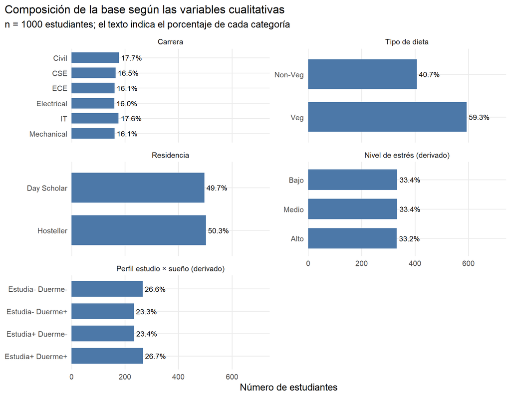

```r
# Orden de niveles para que las barras respeten el orden natural de cada variable.
niveles_grupos <- unique(unlist(lapply(datos[categoricas_todas], levels)))
# Barras horizontales facetadas por variable; el texto muestra el porcentaje.
grafico_barras <- tabla_frecuencias |>
  dplyr::mutate(Categoria = factor(Categoria, levels = rev(niveles_grupos)),
                Variable = factor(Variable, levels = etiquetas[categoricas_todas])) |>
  ggplot2::ggplot(ggplot2::aes(x = Frecuencia, y = Categoria)) +
  ggplot2::geom_col(fill = "#4C78A8", width = 0.7) +
  ggplot2::geom_text(ggplot2::aes(label = Porcentaje), hjust = -0.1, size = 3.2) +
  ggplot2::facet_wrap(~ Variable, scales = "free_y", ncol = 2) +
  ggplot2::scale_x_continuous(expand = ggplot2::expansion(mult = c(0, 0.25))) +
  ggplot2::labs(title = "Composición de la base según las variables cualitativas",
                subtitle = paste0("n = ", n_final, " estudiantes; el texto indica el porcentaje de cada categoría"),
                x = "Número de estudiantes", y = NULL) +
  tema_base
grafico_barras
```

```r
# Exporta a 300 dpi para las láminas.
ggplot2::ggsave("figuras/06_barras_categoricas.png", grafico_barras, width = 9, height = 7, dpi = 300)
```

**Análisis del resultado.** Las categóricas a priori están **equilibradas**: la carrera dominante es Civil (17.7%) y la minoritaria Electrical (16.0%); residencia se reparte casi por mitades y la dieta vegetariana domina con 59.3%. Las derivadas son equilibradas por construcción. Ninguna categoría es tan pequeña que exija moderar las conclusiones.

# 8 Variables cuantitativas: centro, dispersión y posición

```r
# Función de resumen: media, mediana, DE, varianza, cuartiles, IQR, extremos, rango y separación media-mediana en DE.
resumen_variable <- function(x) {
  c(Media = mean(x), Mediana = median(x), DE = sd(x), Varianza = var(x),
    Q1 = unname(quantile(x, 0.25)), Q3 = unname(quantile(x, 0.75)), IQR = IQR(x),
    Mínimo = min(x), Máximo = max(x), Rango = diff(range(x)),
    `(Media − Mediana)/DE` = (mean(x) - median(x)) / sd(x))
}
# Aplica la función a las nueve cuantitativas y transpone para tener una fila por variable.
tabla_resumen <- t(vapply(datos[cuantitativas], resumen_variable, numeric(11)))
rownames(tabla_resumen) <- etiquetas[cuantitativas]
knitr::kable(tabla_resumen, digits = 2, caption = "Resumen numérico de las variables cuantitativas.")
```

Resumen numérico de las variables cuantitativas.

|  | Media | Mediana | DE | Varianza | Q1 | Q3 | IQR | Mínimo | Máximo | Rango | (Media − Mediana)/DE |
| --- | --- | --- | --- | --- | --- | --- | --- | --- | --- | --- | --- |
| Edad (años) | 20.90 | 21.00 | 2.60 | 6.78 | 19.00 | 23.00 | 4.00 | 17.00 | 25.00 | 8.00 | -0.04 |
| Horas de estudio por día | 4.04 | 4.09 | 1.43 | 2.06 | 3.02 | 5.03 | 2.01 | 0.50 | 8.05 | 7.55 | -0.04 |
| Horas de sueño por día | 6.53 | 6.52 | 1.21 | 1.45 | 5.71 | 7.38 | 1.67 | 3.00 | 10.00 | 7.00 | 0.01 |
| Horas de pantalla por día | 4.95 | 4.96 | 1.97 | 3.89 | 3.49 | 6.37 | 2.88 | 1.00 | 10.84 | 9.84 | 0.00 |
| Horas de gimnasio por semana | 7.31 | 6.97 | 4.95 | 24.50 | 3.45 | 10.78 | 7.33 | 0.00 | 21.00 | 21.00 | 0.07 |
| Asistencia (%) | 80.08 | 80.21 | 8.58 | 73.59 | 74.31 | 86.17 | 11.86 | 54.66 | 100.00 | 45.34 | -0.01 |
| Nivel de estrés (1–10) | 4.58 | 4.54 | 2.02 | 4.10 | 3.10 | 5.96 | 2.87 | 1.00 | 10.00 | 9.00 | 0.02 |
| Notas internas (0–100) | 65.92 | 65.60 | 10.12 | 102.48 | 59.33 | 72.55 | 13.22 | 35.00 | 93.93 | 58.93 | 0.03 |
| CGPA (0–10) | 7.32 | 7.30 | 0.95 | 0.91 | 6.69 | 7.99 | 1.30 | 4.00 | 10.00 | 6.00 | 0.02 |

```r
# Clase modal de Sturges para las continuas (la moda del valor exacto carece de sentido con cientos de valores distintos).
clase_modal <- vapply(cuantitativas, function(v) {
  h <- hist(datos[[v]], breaks = "Sturges", plot = FALSE)
  i <- which.max(h$counts)
  sprintf("[%s, %s) con %d estudiantes", format(h$breaks[i]), format(h$breaks[i + 1]), h$counts[i])
}, character(1))
knitr::kable(data.frame(Variable = etiquetas[cuantitativas], `Clase modal (Sturges)` = clase_modal,
                        check.names = FALSE, row.names = NULL),
             caption = "Clase modal de cada variable.")
```

Clase modal de cada variable.

| Variable | Clase modal (Sturges) |
| --- | --- |
| Edad (años) | [17, 18) con 229 estudiantes |
| Horas de estudio por día | [4, 4.5) con 146 estudiantes |
| Horas de sueño por día | [6.5, 7) con 169 estudiantes |
| Horas de pantalla por día | [4, 5) con 184 estudiantes |
| Horas de gimnasio por semana | [0, 2) con 174 estudiantes |
| Asistencia (%) | [75, 80) con 214 estudiantes |
| Nivel de estrés (1–10) | [4, 5) con 199 estudiantes |
| Notas internas (0–100) | [60, 65) con 197 estudiantes |
| CGPA (0–10) | [7, 7.5) con 217 estudiantes |

```r
# Moda exacta solo para la variable discreta (edad), con su frecuencia y empates.
moda_edad <- datos |> dplyr::count(age, sort = TRUE) |> dplyr::slice_max(n, with_ties = TRUE)
moda_edad
```

| age | n |
| --- | --- |
| 17 | 136 |

**Análisis del resultado.** El CGPA promedia 7.32 (mediana 7.30, DE 0.95), con el 50 % central entre 6.69 y 7.99. Los estudiantes estudian en promedio 4.04 h y duermen 6.53 h. En todas las variables la separación media–mediana es menor de 0.07 DE, compatible con simetría; la mayor corresponde a gimnasio (0.07 DE, media por encima de la mediana: cola derecha). La moda exacta solo se reporta para la edad (17 años, 136 estudiantes); para las continuas se usa la clase modal. Las DE no se comparan entre variables porque las unidades difieren; el ACP resolverá eso estandarizando.

# 9 Forma de las distribuciones

```r
# Coeficiente de asimetría por momentos: m3 / m2^(3/2).
coef_asimetria <- function(x) { m <- mean(x); mean((x - m)^3) / mean((x - m)^2)^1.5 }
# Exceso de curtosis: m4 / m2^2 − 3.
exceso_curtosis <- function(x) { m <- mean(x); mean((x - m)^4) / mean((x - m)^2)^2 - 3 }
# Conteo de valores fuera de los bigotes (regla 1.5·IQR).
extremos_iqr <- function(x) { q <- quantile(x, c(0.25, 0.75)); i <- IQR(x); sum(x < q[1] - 1.5 * i | x > q[2] + 1.5 * i) }
# Tabla de forma para las nueve cuantitativas.
tabla_forma <- data.frame(
  Variable = etiquetas[cuantitativas],
  Asimetría = vapply(datos[cuantitativas], coef_asimetria, numeric(1)),
  `Exceso de curtosis` = vapply(datos[cuantitativas], exceso_curtosis, numeric(1)),
  `Clases Sturges` = vapply(datos[cuantitativas], function(x) as.integer(nclass.Sturges(x)), integer(1)),
  `Extremos 1.5·IQR` = vapply(datos[cuantitativas], extremos_iqr, integer(1)),
  check.names = FALSE, row.names = NULL
)
knitr::kable(tabla_forma, digits = 3, caption = "Forma de las distribuciones y valores extremos.")
```

Forma de las distribuciones y valores extremos.

| Variable | Asimetría | Exceso de curtosis | Clases Sturges | Extremos 1.5·IQR |
| --- | --- | --- | --- | --- |
| Edad (años) | 0.017 | -1.232 | 11 | 0 |
| Horas de estudio por día | -0.009 | -0.232 | 11 | 1 |
| Horas de sueño por día | -0.047 | -0.186 | 11 | 5 |
| Horas de pantalla por día | 0.063 | -0.424 | 11 | 1 |
| Horas de gimnasio por semana | 0.440 | -0.314 | 11 | 0 |
| Asistencia (%) | -0.115 | -0.310 | 11 | 4 |
| Nivel de estrés (1–10) | 0.173 | -0.518 | 11 | 0 |
| Notas internas (0–100) | -0.027 | -0.144 | 11 | 6 |
| CGPA (0–10) | -0.063 | 0.249 | 11 | 13 |

```r
# Tabla de frecuencias agrupadas (Sturges) para la variable respuesta.
h_cgpa <- hist(datos$cgpa, breaks = "Sturges", plot = FALSE)
tabla_sturges_cgpa <- data.frame(
  Clase = paste0("[", format(h_cgpa$breaks[-length(h_cgpa$breaks)]), ", ", format(h_cgpa$breaks[-1]), ")"),
  Frecuencia = h_cgpa$counts,
  `Frec. relativa` = round(h_cgpa$counts / sum(h_cgpa$counts), 3),
  `Frec. acumulada` = cumsum(h_cgpa$counts),
  check.names = FALSE
)
knitr::kable(tabla_sturges_cgpa, caption = "Frecuencias agrupadas del CGPA con la regla de Sturges.")
```

Frecuencias agrupadas del CGPA con la regla de Sturges.

| Clase | Frecuencia | Frec. relativa | Frec. acumulada |
| --- | --- | --- | --- |
| [4.0, 4.5) | 6 | 0.006 | 6 |
| [4.5, 5.0) | 3 | 0.003 | 9 |
| [5.0, 5.5) | 13 | 0.013 | 22 |
| [5.5, 6.0) | 55 | 0.055 | 77 |
| [6.0, 6.5) | 110 | 0.110 | 187 |
| [6.5, 7.0) | 185 | 0.185 | 372 |
| [7.0, 7.5) | 217 | 0.217 | 589 |
| [7.5, 8.0) | 167 | 0.167 | 756 |
| [8.0, 8.5) | 143 | 0.143 | 899 |
| [8.5, 9.0) | 61 | 0.061 | 960 |
| [9.0, 9.5) | 29 | 0.029 | 989 |
| [9.5, 10.0) | 11 | 0.011 | 1000 |

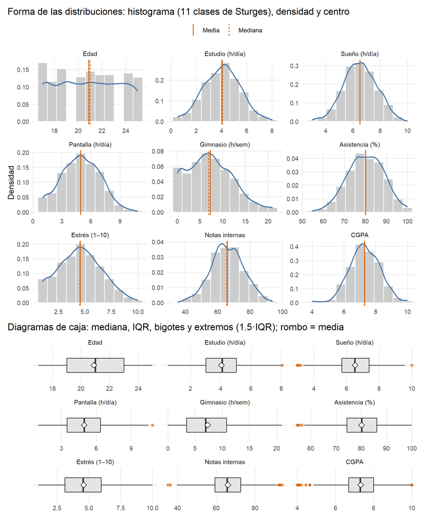

```r
# Formato largo: una fila por estudiante y variable.
datos_largos <- datos |>
  dplyr::select(dplyr::all_of(cuantitativas)) |>
  tidyr::pivot_longer(dplyr::everything(), names_to = "Variable", values_to = "Valor") |>
  dplyr::mutate(Variable = factor(etiquetas_cortas[Variable], levels = etiquetas_cortas))
# Media y mediana por variable para las líneas de referencia.
referencias <- datos_largos |>
  dplyr::group_by(Variable) |>
  dplyr::summarise(Media = mean(Valor), Mediana = median(Valor), .groups = "drop") |>
  tidyr::pivot_longer(c(Media, Mediana), names_to = "Medida", values_to = "Valor")
# Histograma en escala de densidad + curva de densidad + líneas de media y mediana, un panel por variable.
grafico_histogramas <- datos_largos |>
  ggplot2::ggplot(ggplot2::aes(x = Valor)) +
  ggplot2::geom_histogram(ggplot2::aes(y = ggplot2::after_stat(density)), bins = 11,
                          fill = "grey80", colour = "white") +
  ggplot2::geom_density(colour = "#4C78A8", linewidth = 0.9) +
  ggplot2::geom_vline(data = referencias, ggplot2::aes(xintercept = Valor, linetype = Medida),
                      colour = "#D55E00", linewidth = 0.7) +
  ggplot2::facet_wrap(~ Variable, scales = "free", ncol = 3) +
  ggplot2::labs(title = "Forma de las distribuciones: histograma (11 clases de Sturges), densidad y centro",
                x = NULL, y = "Densidad", linetype = NULL) +
  tema_base + ggplot2::theme(legend.position = "top")
# Boxplots con la media como rombo blanco, un panel por variable.
grafico_cajas <- datos_largos |>
  ggplot2::ggplot(ggplot2::aes(x = Valor, y = "")) +
  ggplot2::geom_boxplot(fill = "grey90", outlier.colour = "#D55E00", outlier.alpha = 0.6, width = 0.5) +
  ggplot2::stat_summary(fun = mean, geom = "point", shape = 23, size = 3, fill = "white") +
  ggplot2::facet_wrap(~ Variable, scales = "free_x", ncol = 3) +
  ggplot2::labs(title = "Diagramas de caja: mediana, IQR, bigotes y extremos (1.5·IQR); rombo = media",
                x = NULL, y = NULL) +
  tema_base
# Apila las dos figuras: forma arriba, cajas abajo.
figura_forma <- grafico_histogramas / grafico_cajas + patchwork::plot_layout(heights = c(1.6, 1))
figura_forma
```

```r
ggplot2::ggsave("figuras/08_forma_cuantitativas.png", figura_forma, width = 9, height = 11, dpi = 300)
```

**Análisis del resultado.** Leídas en secuencia histograma → media/mediana → boxplot: (1) todas las variables son unimodales o planas, sin huecos; la edad es **plana** (curtosis -1.23, propia de una uniforme discreta) y gimnasio tiene cola derecha (asimetría 0.44). (2) Media y mediana casi coinciden en las nueve variables. (3) Los boxplots muestran pocos extremos: 13 en CGPA y 6 en notas internas, en ambas colas; son estudiantes con promedios muy altos o muy bajos, **no errores**, y no se eliminan. **Decisión:** por la simetría se reporta **media y DE** como medidas principales, con mediana e IQR de respaldo.

# 10 Comparación entre grupos

```r
# Medianas de CGPA, estudio, sueño y estrés dentro de cada categoría de las cinco categóricas.
tabla_grupos <- purrr::map_dfr(categoricas_todas, function(v) {
  datos |>
    dplyr::group_by(Grupo = as.character(.data[[v]])) |>
    dplyr::summarise(n = dplyr::n(),
                     `CGPA mediana` = median(cgpa), `CGPA media` = mean(cgpa), `CGPA DE` = sd(cgpa),
                     `Estudio mediana` = median(study_hours_per_day),
                     `Sueño mediana` = median(sleep_hours),
                     `Estrés mediana` = median(stress_level_1_to_10), .groups = "drop") |>
    dplyr::mutate(Variable = etiquetas[[v]]) |>
    dplyr::select(Variable, dplyr::everything())
})
knitr::kable(tabla_grupos, digits = 2, caption = "Resumen del CGPA y de los hábitos por grupo.")
```

Resumen del CGPA y de los hábitos por grupo.

| Variable | Grupo | n | CGPA mediana | CGPA media | CGPA DE | Estudio mediana | Sueño mediana | Estrés mediana |
| --- | --- | --- | --- | --- | --- | --- | --- | --- |
| Carrera | CSE | 165 | 7.04 | 7.20 | 0.95 | 3.92 | 6.45 | 4.33 |
| Carrera | Civil | 177 | 7.53 | 7.53 | 0.83 | 4.31 | 6.74 | 4.80 |
| Carrera | ECE | 161 | 7.28 | 7.30 | 0.97 | 4.14 | 6.34 | 4.70 |
| Carrera | Electrical | 160 | 7.21 | 7.23 | 1.02 | 3.99 | 6.27 | 4.57 |
| Carrera | IT | 176 | 7.35 | 7.31 | 0.99 | 3.98 | 6.57 | 4.48 |
| Carrera | Mechanical | 161 | 7.27 | 7.32 | 0.94 | 4.17 | 6.64 | 4.52 |
| Tipo de dieta | Non-Veg | 407 | 7.27 | 7.29 | 0.92 | 4.07 | 6.45 | 4.64 |
| Tipo de dieta | Veg | 593 | 7.31 | 7.34 | 0.98 | 4.12 | 6.55 | 4.49 |
| Residencia | Day Scholar | 497 | 7.29 | 7.29 | 0.96 | 4.04 | 6.47 | 4.48 |
| Residencia | Hosteller | 503 | 7.30 | 7.34 | 0.95 | 4.17 | 6.55 | 4.66 |
| Nivel de estrés (derivado) | Alto | 332 | 7.13 | 7.15 | 0.99 | 5.10 | 5.83 | 6.66 |
| Nivel de estrés (derivado) | Bajo | 334 | 7.48 | 7.48 | 0.96 | 2.91 | 7.40 | 2.50 |
| Nivel de estrés (derivado) | Medio | 334 | 7.30 | 7.33 | 0.89 | 4.06 | 6.37 | 4.54 |
| Perfil estudio × sueño (derivado) | Estudia+ Duerme+ | 267 | 8.17 | 8.19 | 0.70 | 5.07 | 7.37 | 4.83 |
| Perfil estudio × sueño (derivado) | Estudia+ Duerme- | 234 | 7.13 | 7.16 | 0.71 | 4.99 | 5.74 | 6.68 |
| Perfil estudio × sueño (derivado) | Estudia- Duerme+ | 233 | 7.36 | 7.37 | 0.75 | 2.85 | 7.40 | 2.28 |
| Perfil estudio × sueño (derivado) | Estudia- Duerme- | 266 | 6.60 | 6.54 | 0.77 | 3.12 | 5.70 | 4.52 |

```r
# Rango de medianas de CGPA dentro de cada variable de agrupación (qué tanto separa cada una).
rango_medianas <- tabla_grupos |>
  dplyr::group_by(Variable) |>
  dplyr::summarise(`Rango de medianas de CGPA` = max(`CGPA mediana`) - min(`CGPA mediana`), .groups = "drop") |>
  dplyr::arrange(dplyr::desc(`Rango de medianas de CGPA`))
knitr::kable(rango_medianas, digits = 2, caption = "Diferencia entre la mayor y la menor mediana de CGPA por variable de agrupación.")
```

Diferencia entre la mayor y la menor mediana de CGPA por variable de agrupación.

| Variable | Rango de medianas de CGPA |
| --- | --- |
| Perfil estudio × sueño (derivado) | 1.58 |
| Carrera | 0.49 |
| Nivel de estrés (derivado) | 0.36 |
| Tipo de dieta | 0.04 |
| Residencia | 0.01 |

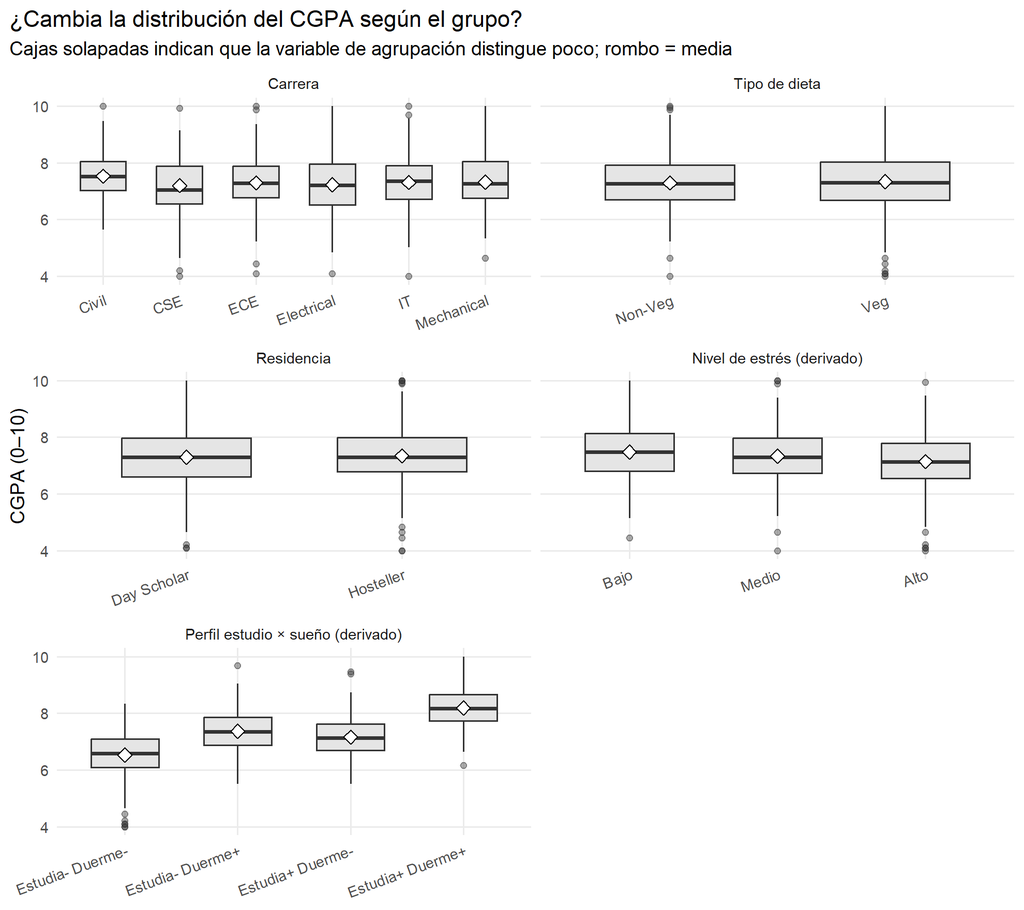

```r
# Formato largo para facetar los boxplots de CGPA por cada categórica.
datos_largos_grupos <- datos |>
  dplyr::select(cgpa, dplyr::all_of(categoricas_todas)) |>
  dplyr::mutate(dplyr::across(dplyr::all_of(categoricas_todas), as.character)) |>
  tidyr::pivot_longer(-cgpa, names_to = "Variable", values_to = "Grupo") |>
  dplyr::mutate(Variable = factor(etiquetas[Variable], levels = etiquetas[categoricas_todas]),
                Grupo = factor(Grupo, levels = niveles_grupos))
# Boxplots de CGPA por grupo; el rombo blanco es la media.
grafico_grupos <- datos_largos_grupos |>
  ggplot2::ggplot(ggplot2::aes(x = Grupo, y = cgpa)) +
  ggplot2::geom_boxplot(fill = "grey90", outlier.alpha = 0.4, width = 0.6) +
  ggplot2::stat_summary(fun = mean, geom = "point", shape = 23, size = 3, fill = "white") +
  ggplot2::facet_wrap(~ Variable, scales = "free_x", ncol = 2) +
  ggplot2::labs(title = "¿Cambia la distribución del CGPA según el grupo?",
                subtitle = "Cajas solapadas indican que la variable de agrupación distingue poco; rombo = media",
                x = NULL, y = "CGPA (0–10)") +
  tema_base + ggplot2::theme(axis.text.x = ggplot2::element_text(angle = 20, hjust = 1))
grafico_grupos
```

```r
ggplot2::ggsave("figuras/09_cgpa_por_grupos.png", grafico_grupos, width = 9, height = 8, dpi = 300)
```

**Análisis del resultado.** Las tres agrupaciones **a priori** apenas mueven el CGPA: entre carreras la mediana varía 0.49 puntos y entre residencias 0.01; las cajas se solapan casi por completo. Las **derivadas** sí ordenan el CGPA: de Bajo a Alto estrés la mediana pasa de 7.48 a 7.13, y entre perfiles va de 6.60 (“Estudia- Duerme-”) a 8.17 (“Estudia+ Duerme+”), un rango de 1.58 puntos. Aun así las cajas de perfiles vecinos se solapan: la diferencia es de promedios, no una separación individual. Lectura descriptiva: en esta base, estudiar y dormir por encima de la mediana **acompaña** promedios más altos; la carrera, la residencia y la dieta no.

# 11 Relaciones bivariadas y correlación

```r
# Matrices de Pearson y Spearman con Hmisc::rcorr (misma muestra analítica).
matriz_numerica <- as.matrix(datos[cuantitativas])
r_pearson <- Hmisc::rcorr(matriz_numerica, type = "pearson")$r
r_spearman <- Hmisc::rcorr(matriz_numerica, type = "spearman")$r
# Pares únicos del triángulo superior, ordenados por magnitud de Pearson.
pares <- which(upper.tri(r_pearson), arr.ind = TRUE)
tabla_pares <- data.frame(
  `Variable 1` = etiquetas_cortas[rownames(r_pearson)[pares[, 1]]],
  `Variable 2` = etiquetas_cortas[colnames(r_pearson)[pares[, 2]]],
  Pearson = r_pearson[pares], Spearman = r_spearman[pares], check.names = FALSE, row.names = NULL
) |>
  dplyr::mutate(`|Pearson − Spearman|` = abs(Pearson - Spearman)) |>
  dplyr::arrange(dplyr::desc(abs(Pearson)))
knitr::kable(head(tabla_pares, 10), digits = 3, caption = "Diez asociaciones más intensas (Pearson) y su Spearman.")
```

Diez asociaciones más intensas (Pearson) y su Spearman.

| Variable 1 | Variable 2 | Pearson | Spearman | \|Pearson − Spearman\| |
| --- | --- | --- | --- | --- |
| Notas internas | CGPA | 0.868 | 0.863 | 0.006 |
| Estudio (h/día) | Asistencia (%) | 0.823 | 0.818 | 0.005 |
| Estudio (h/día) | Estrés (1–10) | 0.654 | 0.642 | 0.012 |
| Sueño (h/día) | CGPA | 0.620 | 0.610 | 0.010 |
| Sueño (h/día) | Estrés (1–10) | -0.580 | -0.559 | 0.021 |
| Asistencia (%) | Estrés (1–10) | 0.536 | 0.523 | 0.013 |
| Sueño (h/día) | Notas internas | 0.527 | 0.505 | 0.022 |
| Estudio (h/día) | CGPA | 0.507 | 0.482 | 0.025 |
| Estudio (h/día) | Notas internas | 0.464 | 0.450 | 0.014 |
| Asistencia (%) | CGPA | 0.422 | 0.404 | 0.018 |

```r
# Par con mayor discrepancia Pearson-Spearman.
par_discrepante <- tabla_pares |> dplyr::slice_max(`|Pearson − Spearman|`, n = 1)
# Mayor |r| de cada variable con cualquier otra (excluida la diagonal).
max_abs_r <- apply(abs(r_pearson) - diag(ncol(r_pearson)), 1, max)
# Variables sin estructura lineal: ninguna correlación alcanza 0.10 en valor absoluto.
sin_estructura <- names(max_abs_r)[max_abs_r < 0.10]
round(max_abs_r, 3)
```

```
##                   age   study_hours_per_day           sleep_hours
##                 0.088                 0.823                 0.620
##     screen_time_hours    gym_hours_per_week attendance_percentage
##                 0.052                 0.088                 0.823
##  stress_level_1_to_10        internal_marks                  cgpa
##                 0.654                 0.868                 0.868
```

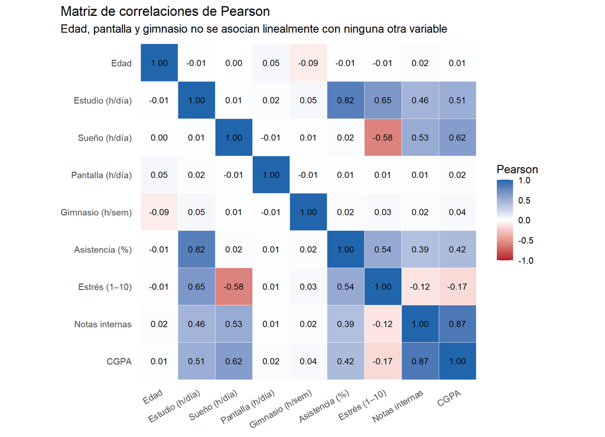

```r
# Matriz de Pearson en formato largo para el mapa de calor.
cor_larga <- as.data.frame(as.table(r_pearson)) |>
  dplyr::mutate(Var1 = factor(etiquetas_cortas[as.character(Var1)], levels = etiquetas_cortas),
                Var2 = factor(etiquetas_cortas[as.character(Var2)], levels = rev(etiquetas_cortas)))
# Mapa de calor con el coeficiente escrito en cada celda.
grafico_correlacion <- cor_larga |>
  ggplot2::ggplot(ggplot2::aes(x = Var1, y = Var2, fill = Freq)) +
  ggplot2::geom_tile(colour = "white") +
  ggplot2::geom_text(ggplot2::aes(label = sprintf("%.2f", Freq)), size = 3.2) +
  ggplot2::scale_fill_gradient2(low = "#B2182B", mid = "white", high = "#2166AC", limits = c(-1, 1), name = "Pearson") +
  ggplot2::coord_equal() +
  ggplot2::labs(title = "Matriz de correlaciones de Pearson",
                subtitle = "Edad, pantalla y gimnasio no se asocian linealmente con ninguna otra variable",
                x = NULL, y = NULL) +
  tema_base + ggplot2::theme(axis.text.x = ggplot2::element_text(angle = 30, hjust = 1), panel.grid = ggplot2::element_blank())
grafico_correlacion
```

```r
ggplot2::ggsave("figuras/10_matriz_correlacion.png", grafico_correlacion, width = 9, height = 6.5, dpi = 300)
```

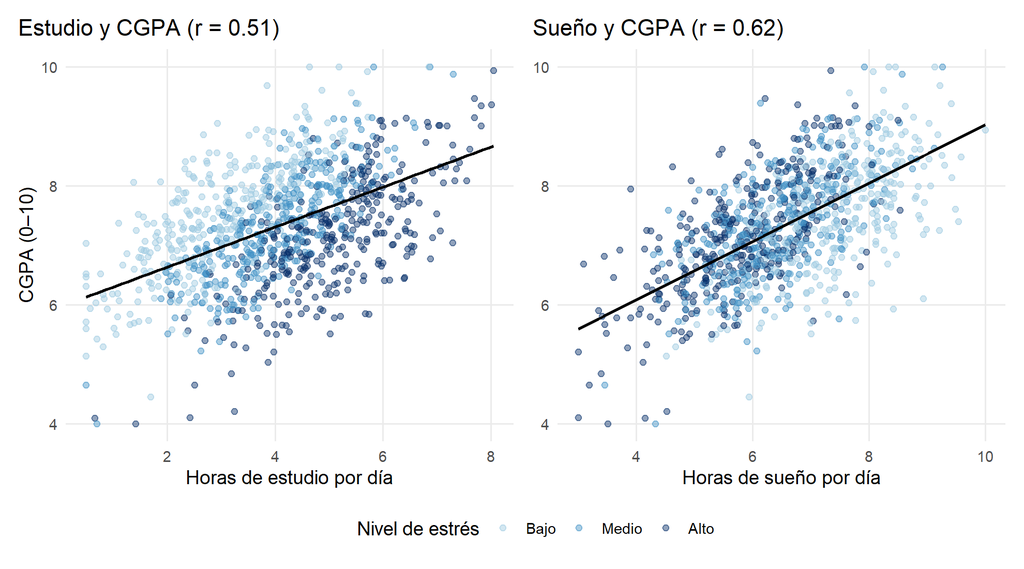

```r
# Dispersión estudio–CGPA y sueño–CGPA, color = nivel de estrés (información, no decoración).
grafico_estudio <- datos |>
  ggplot2::ggplot(ggplot2::aes(x = study_hours_per_day, y = cgpa, colour = nivel_estres)) +
  ggplot2::geom_point(alpha = 0.45, size = 1.6) +
  ggplot2::geom_smooth(method = "lm", se = FALSE, colour = "black", linewidth = 0.8) +
  ggplot2::scale_colour_manual(values = paleta_estres) +
  ggplot2::labs(x = "Horas de estudio por día", y = "CGPA (0–10)", colour = "Nivel de estrés",
                title = sprintf("Estudio y CGPA (r = %.2f)", r_pearson["study_hours_per_day", "cgpa"])) +
  tema_base
grafico_sueno <- datos |>
  ggplot2::ggplot(ggplot2::aes(x = sleep_hours, y = cgpa, colour = nivel_estres)) +
  ggplot2::geom_point(alpha = 0.45, size = 1.6) +
  ggplot2::geom_smooth(method = "lm", se = FALSE, colour = "black", linewidth = 0.8) +
  ggplot2::scale_colour_manual(values = paleta_estres) +
  ggplot2::labs(x = "Horas de sueño por día", y = NULL, colour = "Nivel de estrés",
                title = sprintf("Sueño y CGPA (r = %.2f)", r_pearson["sleep_hours", "cgpa"])) +
  tema_base
# Dos paneles lado a lado con una sola leyenda.
figura_dispersion <- (grafico_estudio | grafico_sueno) +
  patchwork::plot_layout(guides = "collect") &
  ggplot2::theme(legend.position = "bottom")
figura_dispersion
```

```r
ggplot2::ggsave("figuras/10_dispersion_estudio_sueno_cgpa.png", figura_dispersion, width = 10, height = 5, dpi = 300)
```

**Análisis del resultado.** La asociación más intensa es Notas internas–CGPA (r = 0.87), seguida de Estudio (h/día)–Asistencia (%) (0.82). El CGPA se asocia positivamente con el sueño (0.62) y con el estudio (0.51) y débilmente en negativo con el estrés (-0.17). El estrés, a su vez, sube con el estudio (0.65) y baja con el sueño (-0.58). Pearson y Spearman coinciden en todos los pares (mayor discrepancia 0.025 en Estudio (h/día)–CGPA), así que las relaciones son aproximadamente lineales y las nubes de puntos lo confirman: el color revela además que los estudiantes de estrés alto se concentran en las horas altas de estudio y bajas de sueño. Tres variables (Edad, Pantalla (h/día), Gimnasio (h/sem)) no alcanzan |r| = 0.10 con ninguna otra. **Decisión para el ACP:** la redundancia entre estudio, asistencia, estrés, sueño, notas internas y CGPA motiva resumirlas en pocas componentes; las tres variables sin estructura **se excluyen como activas** porque no aportan covariación (solo añadirían ruido al plano) y quedan descritas en las secciones anteriores.

# 12 Análisis de Componentes Principales

```r
# Variables activas: las seis con estructura correlacional.
variables_activas <- c("study_hours_per_day", "sleep_hours", "attendance_percentage",
                       "stress_level_1_to_10", "internal_marks", "cgpa")
matriz_activa <- datos[variables_activas]
# Verificación previa: ninguna variable puede tener DE nula o no disponible.
desviaciones <- vapply(matriz_activa, sd, numeric(1))
if (any(is.na(desviaciones) | desviaciones == 0)) stop("Hay variables sin varianza: no se puede estandarizar.")
# Único ajuste del ACP en todo el documento: centrado y estandarizado (escalas incompatibles: horas, %, puntos).
acp_habitos <- prcomp(matriz_activa, center = TRUE, scale. = TRUE)
# El signo de cada componente es arbitrario: se orienta CP1 para que el CGPA cargue positivo
# y CP2 para que el estrés cargue positivo. Es un cambio de signo, no de geometría.
signo_cp1 <- ifelse(acp_habitos$rotation["cgpa", 1] < 0, -1, 1)
signo_cp2 <- ifelse(acp_habitos$rotation["stress_level_1_to_10", 2] < 0, -1, 1)
acp_habitos$rotation[, 1] <- signo_cp1 * acp_habitos$rotation[, 1]
acp_habitos$x[, 1] <- signo_cp1 * acp_habitos$x[, 1]
acp_habitos$rotation[, 2] <- signo_cp2 * acp_habitos$rotation[, 2]
acp_habitos$x[, 2] <- signo_cp2 * acp_habitos$x[, 2]
# Valores propios, proporción de varianza y acumulada.
valores_propios <- acp_habitos$sdev^2
proporcion_varianza <- valores_propios / sum(valores_propios)
acumulada <- cumsum(proporcion_varianza)
# Criterios de retención.
n_kaiser <- sum(valores_propios > 1)
n_80 <- which(acumulada >= 0.80)[1]
porcentaje_plano <- 100 * sum(proporcion_varianza[1:2])
tabla_varianza <- data.frame(Componente = paste0("CP", seq_along(valores_propios)),
                             `Valor propio` = valores_propios,
                             `% varianza` = 100 * proporcion_varianza,
                             `% acumulado` = 100 * acumulada, check.names = FALSE)
knitr::kable(tabla_varianza, digits = 2, caption = "Valores propios y varianza explicada.")
```

Valores propios y varianza explicada.

| Componente | Valor propio | % varianza | % acumulado |
| --- | --- | --- | --- |
| CP1 | 2.96 | 49.37 | 49.37 |
| CP2 | 2.24 | 37.26 | 86.62 |
| CP3 | 0.38 | 6.36 | 92.99 |
| CP4 | 0.22 | 3.73 | 96.72 |
| CP5 | 0.13 | 2.14 | 98.86 |
| CP6 | 0.07 | 1.14 | 100.00 |

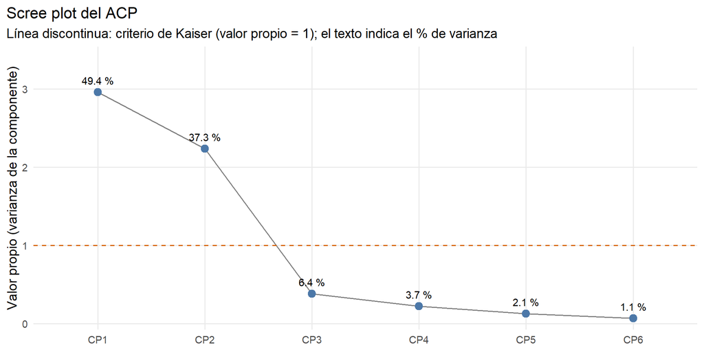

```r
# Scree plot: valores propios por componente; la línea en 1 es la referencia de Kaiser.
grafico_scree <- tabla_varianza |>
  ggplot2::ggplot(ggplot2::aes(x = Componente, y = `Valor propio`, group = 1)) +
  ggplot2::geom_line(colour = "grey50") +
  ggplot2::geom_point(size = 3, colour = "#4C78A8") +
  ggplot2::geom_hline(yintercept = 1, linetype = "dashed", colour = "#D55E00") +
  ggplot2::geom_text(ggplot2::aes(label = sprintf("%.1f %%", `% varianza`)), vjust = -1, size = 3.3) +
  ggplot2::scale_y_continuous(expand = ggplot2::expansion(mult = c(0.05, 0.2))) +
  ggplot2::labs(title = "Scree plot del ACP",
                subtitle = "Línea discontinua: criterio de Kaiser (valor propio = 1); el texto indica el % de varianza",
                x = NULL, y = "Valor propio (varianza de la componente)") +
  tema_base
grafico_scree
```

```r
ggplot2::ggsave("figuras/11_scree.png", grafico_scree, width = 9, height = 4.5, dpi = 300)
```

**Análisis del resultado.** Se estandariza (`scale. = TRUE`) porque horas, porcentajes y puntos no comparten escala: sin ello la asistencia (DE 8.6) dominaría la primera componente. Los valores propios son 2.96, 2.24, 0.38, 0.22, 0.13, 0.07. **Kaiser** retiene 2 componentes, el **criterio del 80 %** exige 2, y el **scree plot** muestra el codo en la tercera componente. Los tres criterios coinciden: dos componentes describen y visualizan la estructura conservando el **86.6 %** de la varianza total (CP1 49.4 %, CP2 37.3 %). El plano CP1–CP2 es, por tanto, una representación de alta calidad.

# 13 Interpretación de las componentes

```r
# Rotaciones: coeficientes de los vectores propios (no son correlaciones ni porcentajes).
rotaciones <- acp_habitos$rotation[, 1:2]
# Correlaciones variable–componente: rotación × desviación de la componente.
cor_var_pc <- sweep(acp_habitos$rotation, 2, acp_habitos$sdev, "*")
# Contribuciones: 100 · rotación²; suman 100 % dentro de cada componente.
contribuciones <- 100 * acp_habitos$rotation^2
# Tabla conjunta de los tres conceptos para CP1 y CP2.
tabla_cargas <- data.frame(
  Variable = etiquetas_cortas[variables_activas],
  `Rotación CP1` = rotaciones[, 1], `Rotación CP2` = rotaciones[, 2],
  `Correlación CP1` = cor_var_pc[, 1], `Correlación CP2` = cor_var_pc[, 2],
  `Contribución CP1 (%)` = contribuciones[, 1], `Contribución CP2 (%)` = contribuciones[, 2],
  check.names = FALSE, row.names = NULL
)
knitr::kable(tabla_cargas, digits = 3, caption = "Rotaciones, correlaciones variable–componente y contribuciones.")
```

Rotaciones, correlaciones variable–componente y contribuciones.

| Variable | Rotación CP1 | Rotación CP2 | Correlación CP1 | Correlación CP2 | Contribución CP1 (%) | Contribución CP2 (%) |
| --- | --- | --- | --- | --- | --- | --- |
| Estudio (h/día) | 0.476 | 0.340 | 0.819 | 0.509 | 22.655 | 11.582 |
| Sueño (h/día) | 0.261 | -0.517 | 0.449 | -0.773 | 6.811 | 26.717 |
| Asistencia (%) | 0.444 | 0.321 | 0.764 | 0.480 | 19.681 | 10.305 |
| Estrés (1–10) | 0.128 | 0.622 | 0.221 | 0.931 | 1.649 | 38.741 |
| Notas internas | 0.487 | -0.239 | 0.838 | -0.357 | 23.692 | 5.694 |
| CGPA | 0.505 | -0.264 | 0.869 | -0.394 | 25.513 | 6.961 |

```r
# Variables ordenadas por |correlación| en cada componente.
orden_cp1 <- variables_activas[order(abs(cor_var_pc[, 1]), decreasing = TRUE)]
orden_cp2 <- variables_activas[order(abs(cor_var_pc[, 2]), decreasing = TRUE)]
# Nombres sustantivos de las componentes, definidos a partir de las cargas y usados en todos los gráficos.
nombre_cp1 <- "dedicación y desempeño"
nombre_cp2 <- "tensión frente a descanso"
```

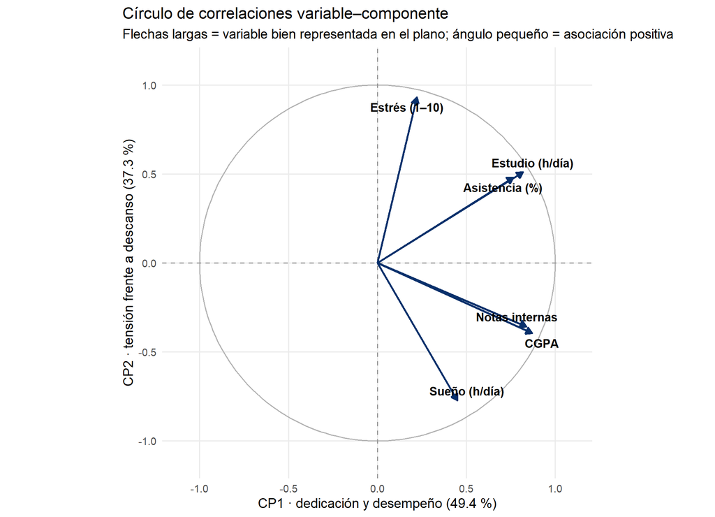

```r
# Círculo de correlaciones: cada variable como flecha (cor CP1, cor CP2) dentro del círculo unitario.
coordenadas_cargas <- data.frame(Variable = etiquetas_cortas[variables_activas],
                                 CP1 = cor_var_pc[, 1], CP2 = cor_var_pc[, 2])
circulo <- data.frame(t = seq(0, 2 * pi, length.out = 200)) |> dplyr::mutate(x = cos(t), y = sin(t))
grafico_cargas <- ggplot2::ggplot() +
  ggplot2::geom_path(data = circulo, ggplot2::aes(x = x, y = y), colour = "grey70") +
  ggplot2::geom_hline(yintercept = 0, linetype = "dashed", colour = "grey60") +
  ggplot2::geom_vline(xintercept = 0, linetype = "dashed", colour = "grey60") +
  ggplot2::geom_segment(data = coordenadas_cargas, ggplot2::aes(x = 0, y = 0, xend = CP1, yend = CP2),
                        arrow = grid::arrow(length = grid::unit(0.22, "cm"), type = "closed"),
                        linewidth = 0.9, colour = "#08306B") +
  ggrepel::geom_text_repel(data = coordenadas_cargas, ggplot2::aes(x = CP1, y = CP2, label = Variable),
                           fontface = "bold", size = 3.8, max.overlaps = Inf) +
  ggplot2::coord_equal(xlim = c(-1.1, 1.1), ylim = c(-1.1, 1.1)) +
  ggplot2::labs(title = "Círculo de correlaciones variable–componente",
                subtitle = "Flechas largas = variable bien representada en el plano; ángulo pequeño = asociación positiva",
                x = sprintf("CP1 · %s (%.1f %%)", nombre_cp1, 100 * proporcion_varianza[1]),
                y = sprintf("CP2 · %s (%.1f %%)", nombre_cp2, 100 * proporcion_varianza[2])) +
  tema_base
grafico_cargas
```

```r
ggplot2::ggsave("figuras/12_cargas_cp1_cp2.png", grafico_cargas, width = 8, height = 8, dpi = 300)
```

**Análisis del resultado.** Los tres conceptos de la tabla son distintos: la rotación es el coeficiente del vector propio, la correlación mide asociación variable–componente y la contribución dice qué proporción de la dirección procede de cada variable. Para nombrar se usan las **correlaciones**:

- **CP1 = dedicación y desempeño.** Correlaciones: CGPA 0.87, notas internas 0.84, horas de estudio 0.82, asistencia 0.76, sueño 0.45; el estrés casi no participa (0.22, contribución 1.6 %). Un valor alto en CP1 describe a un estudiante que estudia, asiste y obtiene notas altas.
- **CP2 = tensión frente a descanso.** Correlaciones: estrés 0.93, sueño -0.77, estudio 0.51, asistencia 0.48; CGPA y notas internas cargan en negativo (-0.39, -0.36). Un valor alto en CP2 describe a quien estudia mucho, duerme poco y reporta más estrés; la componente **opone** la tensión al descanso.

El **signo es arbitrario**: se orientó CP1 hacia el CGPA alto y CP2 hacia el estrés alto solo para facilitar la lectura; otra instalación de R podría invertirlos sin cambiar la geometría, por lo que la interpretación habla de oposiciones y no de “positivo” o “negativo” absolutos.

# 14 Construcción del Biplot

```r
# Puntuaciones (scores) de cada estudiante en CP1 y CP2, con las variables de agrupación.
puntuaciones <- data.frame(Estudiante = seq_len(n_final),
                           CP1 = acp_habitos$x[, 1], CP2 = acp_habitos$x[, 2],
                           nivel_estres = datos$nivel_estres, perfil_habitos = datos$perfil_habitos,
                           branch = datos$branch, residence = datos$residence, diet_type = datos$diet_type)
# Distancia al origen en el plano: perfil estandarizado alejado del centro.
puntuaciones$Distancia <- sqrt(puntuaciones$CP1^2 + puntuaciones$CP2^2)
# Se etiquetan solo los seis estudiantes más alejados.
extremos <- puntuaciones[order(puntuaciones$Distancia, decreasing = TRUE)[1:6], ]
# Coordenadas de las flechas: correlaciones variable–componente.
coordenadas_variables <- data.frame(Variable = etiquetas_cortas[variables_activas],
                                    CP1 = cor_var_pc[, 1], CP2 = cor_var_pc[, 2])
# Un único factor visual lleva las correlaciones (escala −1 a 1) al lienzo de los scores.
factor_flechas <- 0.75 * min(max(abs(puntuaciones$CP1)) / max(abs(coordenadas_variables$CP1)),
                             max(abs(puntuaciones$CP2)) / max(abs(coordenadas_variables$CP2)))
coordenadas_variables$CP1_grafico <- coordenadas_variables$CP1 * factor_flechas
coordenadas_variables$CP2_grafico <- coordenadas_variables$CP2 * factor_flechas
# Única definición del Biplot: cambia solo la variable suplementaria de color y su paleta.
dibujar_biplot <- function(variable_grupo, paleta, titulo, nombre_leyenda) {
  # Grupos con al menos tres observaciones (condición mínima para una elipse).
  conteo <- table(puntuaciones[[variable_grupo]])
  datos_elipses <- puntuaciones[puntuaciones[[variable_grupo]] %in% names(conteo[conteo >= 3]), ]
  # Centroides por grupo.
  centroides <- puntuaciones |>
    dplyr::group_by(Grupo = .data[[variable_grupo]]) |>
    dplyr::summarise(CP1 = mean(CP1), CP2 = mean(CP2), .groups = "drop")
  ggplot2::ggplot() +
    # Ejes de referencia por el origen.
    ggplot2::geom_hline(yintercept = 0, linetype = "dashed", linewidth = 0.4, colour = "grey60") +
    ggplot2::geom_vline(xintercept = 0, linetype = "dashed", linewidth = 0.4, colour = "grey60") +
    # Estudiantes: puntos pequeños y translúcidos (n = 1 000) coloreados por el grupo suplementario.
    ggplot2::geom_point(data = puntuaciones,
                        ggplot2::aes(x = CP1, y = CP2, colour = .data[[variable_grupo]]),
                        size = 1.5, alpha = 0.35) +
    # Elipses descriptivas (normal, 95 %) por grupo.
    ggplot2::stat_ellipse(data = datos_elipses,
                          ggplot2::aes(x = CP1, y = CP2, colour = .data[[variable_grupo]]),
                          type = "norm", level = 0.95, linewidth = 1, linetype = "longdash") +
    # Centroides: rombos grandes con borde negro.
    ggplot2::geom_point(data = centroides, ggplot2::aes(x = CP1, y = CP2, fill = Grupo),
                        shape = 23, size = 5, colour = "black", stroke = 0.9) +
    # Etiquetas de los seis estudiantes más alejados del origen.
    ggrepel::geom_text_repel(data = extremos, ggplot2::aes(x = CP1, y = CP2, label = paste0("Est. ", Estudiante)),
                             size = 3, colour = "grey30", max.overlaps = Inf) +
    # Flechas de las variables activas (escaladas con el factor visual común).
    ggplot2::geom_segment(data = coordenadas_variables,
                          ggplot2::aes(x = 0, y = 0, xend = CP1_grafico, yend = CP2_grafico),
                          arrow = grid::arrow(length = grid::unit(0.22, "cm"), type = "closed"),
                          linewidth = 0.9, colour = "black") +
    # Nombres de las variables junto a las puntas, con halo blanco para leerse sobre los puntos.
    ggrepel::geom_text_repel(data = coordenadas_variables,
                             ggplot2::aes(x = CP1_grafico, y = CP2_grafico, label = Variable),
                             fontface = "bold", size = 3.8, colour = "black",
                             bg.color = "white", bg.r = 0.15, max.overlaps = Inf) +
    ggplot2::scale_colour_manual(values = paleta, name = nombre_leyenda) +
    ggplot2::scale_fill_manual(values = paleta, guide = "none") +
    # Misma unidad visual en ambos ejes: indispensable para leer ángulos.
    ggplot2::coord_equal(clip = "off") +
    ggplot2::labs(
      title = titulo,
      subtitle = sprintf("CP1 + CP2 conservan el %.1f %% de la variabilidad de las 6 variables activas · n = %d estudiantes",
                         porcentaje_plano, n_final),
      x = sprintf("CP1 · %s (%.1f %%)", nombre_cp1, 100 * proporcion_varianza[1]),
      y = sprintf("CP2 · %s (%.1f %%)", nombre_cp2, 100 * proporcion_varianza[2]),
      caption = sprintf(paste0("Puntos: estudiantes (scores). Flechas: correlaciones variable–componente × factor visual común %.2f (solo escala, conserva ángulos).\n",
                               "Elipses: normal al 95 %%, descriptivas. Rombos: centroides.
",
                               "El grupo de color no interviene en el ACP; deriva de variables activas, por lo que su separación es esperable por construcción."),
                        factor_flechas)
    ) +
    tema_base + ggplot2::theme(legend.position = "bottom")
}
c(factor_flechas = round(factor_flechas, 3))
```

```
## factor_flechas
##          3.398
```

## 14.1 Biplot A: nivel de estrés

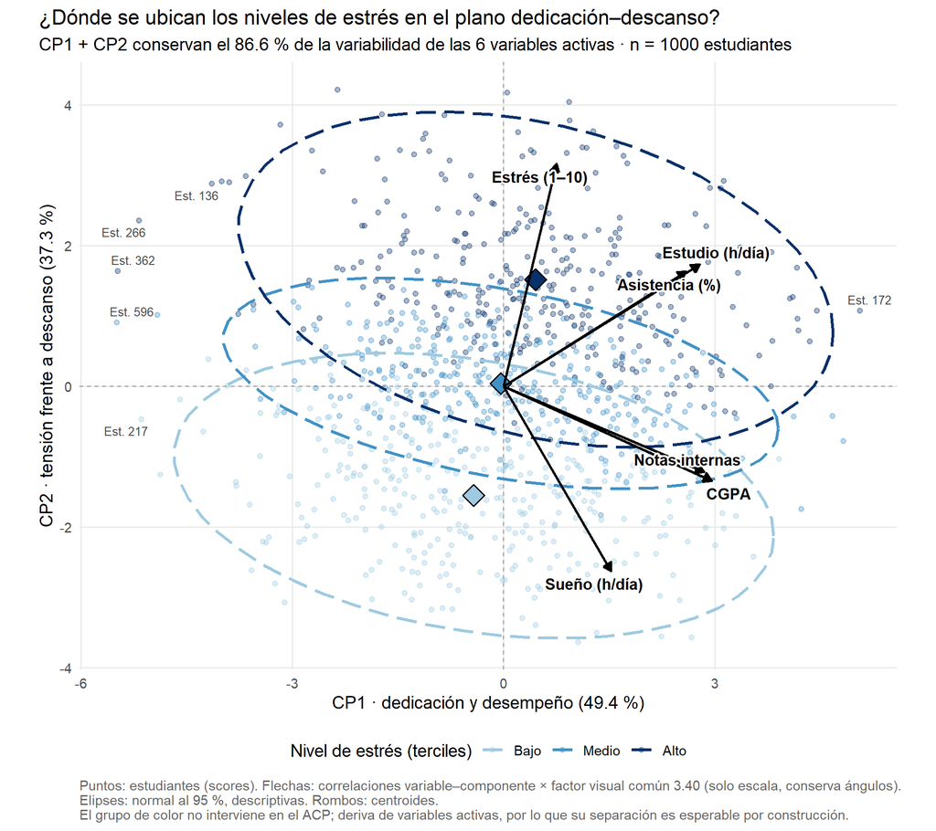

```r
biplot_estres <- dibujar_biplot("nivel_estres", paleta_estres,
                                "¿Dónde se ubican los niveles de estrés en el plano dedicación–descanso?",
                                "Nivel de estrés (terciles)")
biplot_estres
```

```r
ggplot2::ggsave("figuras/13_biplot_nivel_estres.png", biplot_estres, width = 9, height = 8, dpi = 300)
```

## 14.2 Biplot B: perfil estudio × sueño

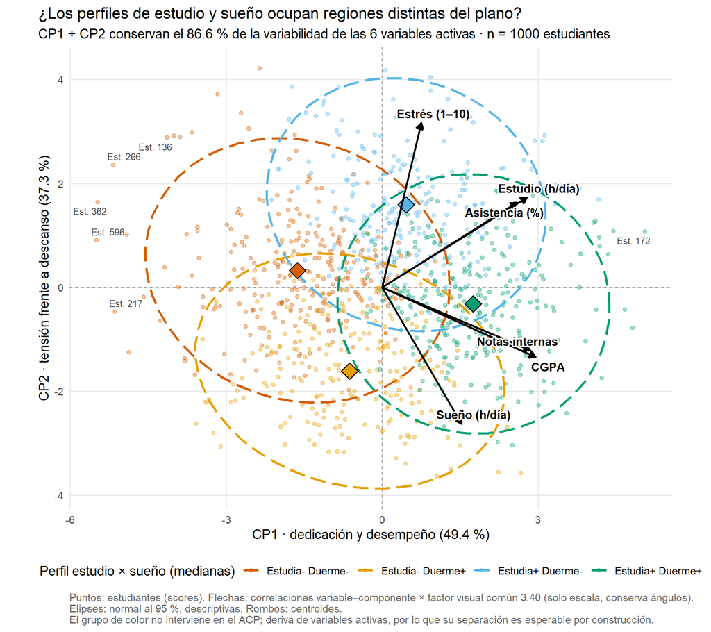

```r
biplot_perfil <- dibujar_biplot("perfil_habitos", paleta_perfil,
                                "¿Los perfiles de estudio y sueño ocupan regiones distintas del plano?",
                                "Perfil estudio × sueño (medianas)")
biplot_perfil
```

```r
ggplot2::ggsave("figuras/13_biplot_perfil_habitos.png", biplot_perfil, width = 9, height = 8, dpi = 300)
```

**Análisis del resultado.** Ambos Biplots son de **correlación**: los puntos son los scores y las flechas las correlaciones variable–componente multiplicadas por un único factor visual (3.40), que conserva direcciones, ángulos y longitudes relativas pero impide leer literalmente la distancia entre la punta de una flecha y un punto. Cada figura responde una sola pregunta escrita en su título; los puntos individuales se atenúan (α = 0.35) y solo se etiquetan los seis más alejados del origen para que la señal (flechas, elipses y centroides) domine sobre el ruido. Los ejes llevan el nombre de la componente y su porcentaje; la leyenda solo codifica el grupo. La interpretación se hace por capas en la sección siguiente.

# 15 Interpretación del Biplot en capas

## 15.1 Capa 1: calidad del plano

El plano conserva el **86.6 %** de la varianza de las seis variables activas. Toda lectura posterior es una aproximación bidimensional; el 13.4 % restante se reparte entre CP3 y siguientes.

## 15.2 Capa 2: calidad de representación de las variables (cos²)

```r
# cos² = suma de las correlaciones al cuadrado con CP1 y CP2.
calidad_variables <- rowSums(cor_var_pc[, 1:2]^2)
tabla_cos2 <- data.frame(Variable = etiquetas_cortas[variables_activas],
                         `cos² en el plano` = calidad_variables,
                         `Longitud de la flecha` = sqrt(calidad_variables), check.names = FALSE, row.names = NULL) |>
  dplyr::arrange(dplyr::desc(`cos² en el plano`))
knitr::kable(tabla_cos2, digits = 3, caption = "Calidad de representación de cada variable en CP1–CP2.")
```

Calidad de representación de cada variable en CP1–CP2.

| Variable | cos² en el plano | Longitud de la flecha |
| --- | --- | --- |
| Estudio (h/día) | 0.930 | 0.964 |
| Estrés (1–10) | 0.915 | 0.956 |
| CGPA | 0.911 | 0.955 |
| Notas internas | 0.829 | 0.911 |
| Asistencia (%) | 0.813 | 0.902 |
| Sueño (h/día) | 0.799 | 0.894 |

## 15.3 Capa 3: ángulos entre flechas frente a la matriz de correlaciones

```r
# Ángulo (en grados) entre dos flechas en el plano CP1–CP2.
angulo_plano <- function(a, b) {
  u <- cor_var_pc[a, 1:2]; v <- cor_var_pc[b, 1:2]
  acos(sum(u * v) / (sqrt(sum(u^2)) * sqrt(sum(v^2)))) * 180 / pi
}
pares_clave <- list(c("study_hours_per_day", "attendance_percentage"), c("internal_marks", "cgpa"),
                    c("stress_level_1_to_10", "sleep_hours"), c("sleep_hours", "cgpa"),
                    c("study_hours_per_day", "cgpa"), c("stress_level_1_to_10", "cgpa"))
tabla_angulos <- purrr::map_dfr(pares_clave, function(p) data.frame(
  `Variable 1` = etiquetas_cortas[p[1]], `Variable 2` = etiquetas_cortas[p[2]],
  `Ángulo en el plano (°)` = angulo_plano(p[1], p[2]),
  `Pearson original` = r_pearson[p[1], p[2]],
  `cos del ángulo` = cos(angulo_plano(p[1], p[2]) * pi / 180), check.names = FALSE, row.names = NULL))
knitr::kable(tabla_angulos, digits = 2, caption = "Ángulos entre flechas y correlaciones originales.")
```

Ángulos entre flechas y correlaciones originales.

| Variable 1 | Variable 2 | Ángulo en el plano (°) | Pearson original | cos del ángulo |
| --- | --- | --- | --- | --- |
| Estudio (h/día) | Asistencia (%) | 0.31 | 0.82 | 1.00 |
| Notas internas | CGPA | 1.34 | 0.87 | 1.00 |
| Estrés (1–10) | Sueño (h/día) | 136.48 | -0.58 | -0.73 |
| Sueño (h/día) | CGPA | 35.43 | 0.62 | 0.81 |
| Estudio (h/día) | CGPA | 56.25 | 0.51 | 0.56 |
| Estrés (1–10) | CGPA | 101.05 | -0.17 | -0.19 |

**Análisis del resultado.** El Biplot reproduce la matriz de correlaciones: estudio y asistencia forman un ángulo de 0.3° (r = 0.82), notas internas y CGPA de 1.3° (r = 0.87); estrés y sueño apuntan casi en direcciones opuestas (136.5°, r = -0.58), y estrés y CGPA quedan cerca de la perpendicular (101.0°, r = -0.17): en el plano retenido casi no comparten información lineal. Un ángulo no es una causa: describe covariación.

## 15.4 Capa 4: posición de las observaciones extremas

```r
# Valores originales de los seis estudiantes más alejados del origen, para explicarlos desde las flechas.
tabla_extremos <- extremos |>
  dplyr::select(Estudiante, CP1, CP2, Distancia, perfil_habitos, nivel_estres) |>
  dplyr::left_join(datos |> dplyr::mutate(Estudiante = seq_len(n_final)) |>
                     dplyr::select(Estudiante, dplyr::all_of(variables_activas)), by = "Estudiante")
names(tabla_extremos) <- c("Estudiante", "CP1", "CP2", "Distancia", "Perfil", "Estrés (nivel)",
                           etiquetas_cortas[variables_activas])
knitr::kable(tabla_extremos, digits = 2, caption = "Seis estudiantes más alejados del origen en CP1–CP2.")
```

Seis estudiantes más alejados del origen en CP1–CP2.

| Estudiante | CP1 | CP2 | Distancia | Perfil | Estrés (nivel) | Estudio (h/día) | Sueño (h/día) | Asistencia (%) | Estrés (1–10) | Notas internas | CGPA |
| --- | --- | --- | --- | --- | --- | --- | --- | --- | --- | --- | --- |
| 362 | -5.47 | 1.64 | 5.71 | Estudia- Duerme- | Alto | 0.66 | 4.15 | 66.41 | 5.60 | 35.00 | 4.09 |
| 266 | -5.17 | 2.35 | 5.68 | Estudia- Duerme- | Alto | 1.42 | 3.51 | 63.67 | 7.14 | 40.84 | 4.00 |
| 596 | -5.49 | 0.91 | 5.56 | Estudia- Duerme- | Medio | 0.50 | 3.46 | 62.19 | 3.75 | 39.71 | 4.65 |
| 172 | 5.06 | 1.07 | 5.17 | Estudia+ Duerme+ | Alto | 8.05 | 7.34 | 100.00 | 7.55 | 85.61 | 9.94 |
| 217 | -5.14 | -0.47 | 5.16 | Estudia- Duerme- | Bajo | 0.50 | 4.51 | 61.36 | 1.38 | 40.90 | 5.14 |
| 136 | -4.14 | 2.88 | 5.04 | Estudia- Duerme- | Alto | 2.42 | 3.00 | 73.95 | 6.62 | 46.26 | 4.10 |

**Análisis del resultado.** El estudiante más alejado (Est. 362, CP1 = -5.47, CP2 = 1.64) se explica desde las flechas: su proyección sobre CGPA y estudio va en la dirección negativa (valores bajos) y sobre estrés en la dirección positiva (estrés alto, sueño bajo). Son perfiles estandarizados **extremos, no atípicos**: combinan valores altos o bajos coherentes en varias variables a la vez, y un estudiante central en este plano podría ser extremo en CP3.

## 15.5 Capa 5: centroides por grupo (fin del alcance)

```r
# Centroides de las cinco categóricas y separación máxima entre centroides dentro de cada variable.
tabla_centroides <- purrr::map_dfr(categoricas_todas, function(v) {
  puntuaciones |>
    dplyr::group_by(Grupo = as.character(.data[[v]])) |>
    dplyr::summarise(n = dplyr::n(), `Centroide CP1` = mean(CP1), `Centroide CP2` = mean(CP2), .groups = "drop") |>
    dplyr::mutate(Variable = etiquetas[[v]]) |>
    dplyr::select(Variable, dplyr::everything())
})
knitr::kable(tabla_centroides, digits = 2, caption = "Centroides de cada grupo en el plano CP1–CP2.")
```

Centroides de cada grupo en el plano CP1–CP2.

| Variable | Grupo | n | Centroide CP1 | Centroide CP2 |
| --- | --- | --- | --- | --- |
| Carrera | CSE | 165 | -0.17 | 0.04 |
| Carrera | Civil | 177 | 0.38 | -0.06 |
| Carrera | ECE | 161 | -0.03 | 0.08 |
| Carrera | Electrical | 160 | -0.10 | 0.09 |
| Carrera | IT | 176 | -0.13 | -0.12 |
| Carrera | Mechanical | 161 | 0.03 | -0.03 |
| Tipo de dieta | Non-Veg | 407 | -0.03 | 0.06 |
| Tipo de dieta | Veg | 593 | 0.02 | -0.04 |
| Residencia | Day Scholar | 497 | -0.10 | -0.02 |
| Residencia | Hosteller | 503 | 0.10 | 0.02 |
| Nivel de estrés (derivado) | Alto | 332 | 0.46 | 1.52 |
| Nivel de estrés (derivado) | Bajo | 334 | -0.42 | -1.55 |
| Nivel de estrés (derivado) | Medio | 334 | -0.04 | 0.04 |
| Perfil estudio × sueño (derivado) | Estudia+ Duerme+ | 267 | 1.76 | -0.32 |
| Perfil estudio × sueño (derivado) | Estudia+ Duerme- | 234 | 0.46 | 1.59 |
| Perfil estudio × sueño (derivado) | Estudia- Duerme+ | 233 | -0.62 | -1.61 |
| Perfil estudio × sueño (derivado) | Estudia- Duerme- | 266 | -1.63 | 0.33 |

```r
# Mayor distancia entre dos centroides de la misma variable.
separacion_centroides <- tabla_centroides |>
  dplyr::group_by(Variable) |>
  dplyr::summarise(`Separación máxima entre centroides` = max(dist(cbind(`Centroide CP1`, `Centroide CP2`))), .groups = "drop") |>
  dplyr::arrange(dplyr::desc(`Separación máxima entre centroides`))
knitr::kable(separacion_centroides, digits = 2, caption = "Separación máxima entre centroides por variable de agrupación.")
```

Separación máxima entre centroides por variable de agrupación.

| Variable | Separación máxima entre centroides |
| --- | --- |
| Perfil estudio × sueño (derivado) | 3.44 |
| Nivel de estrés (derivado) | 3.20 |
| Carrera | 0.56 |
| Residencia | 0.19 |
| Tipo de dieta | 0.10 |

**Análisis del resultado.** En el **Biplot A** los centroides de estrés se alinean con CP2: Bajo en CP2 = -1.55 y Alto en 1.52, con un leve desplazamiento en CP1 (-0.42 frente a 0.46): el grupo de estrés alto se ubica algo más hacia la dedicación porque estudia y asiste más, pero su CGPA mediano es menor (7.13 frente a 7.48): en esta base el estrés se alinea con las horas de estudio, no con la nota. En el **Biplot B** los cuatro perfiles ocupan los cuatro cuadrantes: “Estudia+ Duerme+” en (1.76, -0.32) y “Estudia- Duerme-” en (-1.63, 0.33), la mayor separación de todas (3.44 unidades). Las elipses, sin embargo, se solapan ampliamente: los centroides difieren, la separación individual es parcial. Las categóricas **a priori** tienen centroides a menos de 0.38 unidades del origen y elipses prácticamente coincidentes: la carrera, la residencia y la dieta no acompañan diferencias en este plano, lo mismo que mostraron las cajas de CGPA. La separación de los grupos derivados es **esperable por construcción** (se definieron con variables activas); el ACP no “encontró” grupos. **Aquí termina el alcance del análisis.**

# 16 Comunicación de resultados

## 16.1 Respuesta descriptiva a la pregunta

En esta base de 1000 estudiantes el CGPA promedia 7.32 (DE 0.95), con distribución simétrica y 13 valores extremos que no se eliminan. Las horas de sueño (r = 0.62) y de estudio (r = 0.51) se asocian positivamente con el CGPA, mientras que edad, pantalla y gimnasio no muestran asociación lineal con nada. El estrés sube con el estudio y baja con el sueño, y apenas se relaciona con el CGPA. Entre carreras, residencias y dietas la mediana del CGPA cambia menos de 0.5 puntos y las cajas se solapan; entre perfiles de hábitos va de 6.60 a 8.17. El ACP resume seis variables en dos ejes (86.6 %): dedicación y desempeño, y tensión frente a descanso; en el Biplot los perfiles y los niveles de estrés ocupan regiones distintas con elipses solapadas. Todo lo anterior describe asociaciones en esta base, probablemente simulada: no demuestra causas ni se extiende a otros estudiantes.

## 16.2 Afirmaciones respaldadas y afirmaciones excesivas

```r
data.frame(
  `Afirmación respaldada por los datos` = c(
    sprintf("Los estudiantes que duermen más tienden a tener CGPA más alto (r = %.2f; flecha de sueño alineada con CGPA).", r_pearson["sleep_hours", "cgpa"]),
    sprintf("CP1 resume dedicación y desempeño: CGPA, notas, estudio y asistencia cargan juntas (correlaciones ≥ %.2f).", min(abs(cor_var_pc[c("cgpa", "internal_marks", "study_hours_per_day", "attendance_percentage"), 1]))),
    "Los centroides de carrera, residencia y dieta están cerca del origen: esas variables no acompañan diferencias en el plano."),
  `Afirmación excesiva o incorrecta` = c(
    "Dormir más causa mejores notas (la base es observacional y probablemente simulada).",
    "El ACP descubrió tres grupos de estrés (los niveles se definieron a priori con una variable activa).",
    "Un estudiante dentro de la elipse 'Estudia+ Duerme+' tiene CGPA alto en todas las variables (la elipse es un resumen, no una frontera)."),
  check.names = FALSE
) |> knitr::kable(caption = "Tres afirmaciones respaldadas frente a tres excesivas.")
```

Tres afirmaciones respaldadas frente a tres excesivas.

| Afirmación respaldada por los datos | Afirmación excesiva o incorrecta |
| --- | --- |
| Los estudiantes que duermen más tienden a tener CGPA más alto (r = 0.62; flecha de sueño alineada con CGPA). | Dormir más causa mejores notas (la base es observacional y probablemente simulada). |
| CP1 resume dedicación y desempeño: CGPA, notas, estudio y asistencia cargan juntas (correlaciones ≥ 0.76). | El ACP descubrió tres grupos de estrés (los niveles se definieron a priori con una variable activa). |
| Los centroides de carrera, residencia y dieta están cerca del origen: esas variables no acompañan diferencias en el plano. | Un estudiante dentro de la elipse ‘Estudia+ Duerme+’ tiene CGPA alto en todas las variables (la elipse es un resumen, no una frontera). |

## 16.3 Decisiones metodológicas

```r
data.frame(
  Decisión = c("Variable respuesta", "Categóricas derivadas", "Media/DE frente a mediana/IQR", "Moda", "Valores extremos",
               "Variables activas del ACP", "Estandarización", "Número de componentes", "Signo de las componentes",
               "Variable de color del Biplot", "Lenguaje"),
  Criterio = c(
    "CGPA: medida final de desempeño con estructura correlacional (r = 0.62 con sueño, 0.51 con estudio).",
    "Terciles del estrés y perfil 2 × 2 por medianas; cortes descriptivos declarados.",
    "Simetría en todas las variables (|asimetría| ≤ 0.44, media ≈ mediana): media/DE con mediana/IQR de respaldo.",
    "Clase modal de Sturges en continuas; moda exacta solo en la edad (discreta).",
    "Regla 1.5·IQR para contarlos; no se eliminan porque son promedios plausibles.",
    "Seis variables con |r| ≥ 0.10 con alguna otra; edad, pantalla y gimnasio excluidas por no covariar (el plano bajaría de 86.6 % a ≈ 58 %).",
    "scale. = TRUE porque horas, porcentajes y puntos tienen escalas incompatibles.",
    "Dos: coinciden Kaiser, 80 % acumulado y codo del scree plot.",
    "Orientadas hacia CGPA alto (CP1) y estrés alto (CP2); el signo es arbitrario y se declara.",
    "Suplementaria (no activa); se advierte que deriva de variables activas y que la separación es esperable por construcción.",
    "'Se asocia', 'acompaña', 'en esta base'; nunca 'causa' ni generalización poblacional."
  )
) |> knitr::kable(caption = "Decisiones metodológicas y su justificación.")
```

Decisiones metodológicas y su justificación.

| Decisión | Criterio |
| --- | --- |
| Variable respuesta | CGPA: medida final de desempeño con estructura correlacional (r = 0.62 con sueño, 0.51 con estudio). |
| Categóricas derivadas | Terciles del estrés y perfil 2 × 2 por medianas; cortes descriptivos declarados. |
| Media/DE frente a mediana/IQR | Simetría en todas las variables (\|asimetría\| ≤ 0.44, media ≈ mediana): media/DE con mediana/IQR de respaldo. |
| Moda | Clase modal de Sturges en continuas; moda exacta solo en la edad (discreta). |
| Valores extremos | Regla 1.5·IQR para contarlos; no se eliminan porque son promedios plausibles. |
| Variables activas del ACP | Seis variables con \|r\| ≥ 0.10 con alguna otra; edad, pantalla y gimnasio excluidas por no covariar (el plano bajaría de 86.6 % a ≈ 58 %). |
| Estandarización | scale. = TRUE porque horas, porcentajes y puntos tienen escalas incompatibles. |
| Número de componentes | Dos: coinciden Kaiser, 80 % acumulado y codo del scree plot. |
| Signo de las componentes | Orientadas hacia CGPA alto (CP1) y estrés alto (CP2); el signo es arbitrario y se declara. |
| Variable de color del Biplot | Suplementaria (no activa); se advierte que deriva de variables activas y que la separación es esperable por construcción. |
| Lenguaje | ‘Se asocia’, ‘acompaña’, ‘en esta base’; nunca ‘causa’ ni generalización poblacional. |

# 17 Apéndice

## 17.1 Correspondencia con la rúbrica

```r
data.frame(
  Criterio = c("Claridad y coherencia de la pregunta (1.0)", "Organización y presentación de los datos (1.0)",
               "Aplicación de técnicas descriptivas (1.5)", "Interpretación y conclusiones (1.5)"),
  `Dónde se evidencia` = c(
    "Sección 1: pregunta con dos cuantitativas, una respuesta y dos categóricas; justificación en cuatro preguntas; objetivos con verbos descriptivos.",
    "Secciones 3–5: tipos verificados, cero faltantes, muestra analítica única, advertencias sobre la base, tabla de variables con rol.",
    "Secciones 7–13: frecuencias, media/mediana/moda/DE/varianza/IQR/rango, Sturges, asimetría y curtosis, boxplots, Pearson y Spearman, ACP con tres criterios de retención, Biplot con factor visual declarado; cada decisión justificada en la tabla de decisiones.",
    "Bloques 'Análisis del resultado' con cifras calculadas en el documento; interpretación del Biplot en cinco capas hasta los centroides; respuesta descriptiva; afirmaciones respaldadas frente a excesivas; alcance delimitado."
  ), check.names = FALSE
) |> knitr::kable(caption = "Correspondencia con los criterios de la rúbrica.")
```

Correspondencia con los criterios de la rúbrica.

[output not shown]